# pp346_ps1_steiner

erika steiner

2025-04-04

## Overarching Questions

1. How did FTP change the behavior of welfare recipients?
2. What can we say about the effects of the time limit as opposed to other components of the program?

## Analysis Questions

2. *Open the file ftp_ar.dta. What is the number of observations? Of observations in the treatment and control groups? Do your numbers match those from the documentation?*

There are 2815 observations in the public use administrative records file. The treatment and control group observations are as follows:

Observations by Treatment Status

| Group | Number of Observations |
| --- | --- |
| Control | 1410 |
| Treatment | 1405 |

These observation counts match those shared on page 8 of the FTP Documentation.

4. *Verify the data by replicating the control-group means in the file “Annotated AR table 1_U.xls.” Restrict attention to the following subset of variables:*
1. *quarterly employment, quarter of RA to quarter 18;*

Average Quarterly Employment Rates among Control Group

| Quarter | Employment Rate (%) |
| --- | --- |
| Quarter of RA* | 33.9 |
| Quarter 1 | 37.3 |
| Quarter 2 | 39.1 |
| Quarter 3 | 39.6 |
| Quarter 4 | 40.7 |
| Quarter 5 | 41.0 |
| Quarter 6 | 41.8 |
| Quarter 7 | 45.2 |
| Quarter 8 | 44.5 |
| Quarter 9 | 45.3 |
| Quarter 10 | 44.2 |
| Quarter 11 | 44.3 |
| Quarter 12 | 44.5 |
| Quarter 13 | 46.3 |
| Quarter 14 | 48.4 |
| Quarter 15 | 48.2 |
| Quarter 16 | 49.1 |
| Quarter 17 | 48.7 |
| Quarter 18 | 49.8 |

* RA = Random Assignment

2. *any AFDC/TANF payments, quarter of RA to quarter 18;*

Average Quarterly AFDC/TANF Receipt Rates among Control Group

| Quarter | Any AFDC/TANF Receipt (%) |
| --- | --- |
| Quarter of RA* | 77.0 |
| Quarter 1 | 77.2 |
| Quarter 2 | 67.4 |
| Quarter 3 | 58.9 |
| Quarter 4 | 54.4 |
| Quarter 5 | 49.9 |
| Quarter 6 | 47.2 |
| Quarter 7 | 42.2 |
| Quarter 8 | 38.6 |
| Quarter 9 | 36.1 |
| Quarter 10 | 33.1 |
| Quarter 11 | 31.1 |
| Quarter 12 | 27.9 |
| Quarter 13 | 24.3 |
| Quarter 14 | 21.3 |
| Quarter 15 | 19.2 |
| Quarter 16 | 17.8 |
| Quarter 17 | 16.5 |
| Quarter 18 | 14.0 |

* RA = Random Assignment

2. *any Food Stamp payments, quarter of RA to quarter 18;*

Average Quarterly Food Stamp Receipt Rates among Control Group

| Quarter | Any Food Stamp Receipt (%) |
| --- | --- |
| Quarter of RA* | 86.5 |
| Quarter 1 | 86.7 |
| Quarter 2 | 78.2 |
| Quarter 3 | 71.4 |
| Quarter 4 | 68.5 |
| Quarter 5 | 65.4 |
| Quarter 6 | 61.8 |
| Quarter 7 | 58.9 |
| Quarter 8 | 56.5 |
| Quarter 9 | 52.5 |
| Quarter 10 | 49.2 |
| Quarter 11 | 47.3 |
| Quarter 12 | 46.9 |
| Quarter 13 | 43.6 |
| Quarter 14 | 42.0 |
| Quarter 15 | 39.7 |
| Quarter 16 | 37.4 |
| Quarter 17 | 36.7 |
| Quarter 18 | 34.2 |

* RA = Random Assignment

*Are there any discrepancies?*

There is one major discrepancy between the “Average Quarterly Food Stamp Receipt Rates among Control Group” table and “AR Table 1_U”. While the above reports that “36.7”% of the control group received food stamps in Quarter 17, the original table reports “0.4”. While 36.7 is similar to the numbers reported in other quarters and follows the general trend, 0.4 is drastically different, implying some error in the original table.

*While you are at it, comment on the levels of employment among the people in the study population.*

On average, the control group appears to increase employment rates over time.

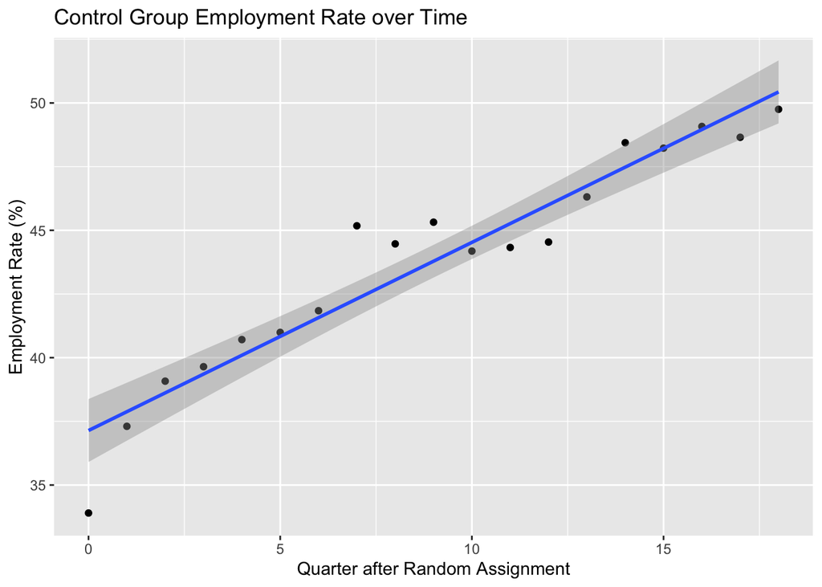

4. *Compare your results to those in Table B.1 of Bloom et al (2000). Why are they different? How do you expect these differences to affect your results?*

The results in Table B.1 are slightly different (percentage rates in the Bloom table are between 0.2 higher and 0.5 lower than those in the results above).

As explained on Page 3 of the data documentation, the files have been changed from their original form to maintain participant confidentiality. This includes top coding some variables, rounding all administrative record variables, and completely dropping some variables (including most date variables). Bloom’s analysis may have thus been able to employ some of the dropped variables to make more precise estimates, while ours did not include the same adjustments. Following up on the the prior question, there may also be differing rounding parameters utilized in the original tables.

We are told, however, that extensive testing has been conducted to confirm that the results in Bloom are very close to those we created. Thus, while we would expect the minor differences we experienced due to some slight data discrepancies, we should not expect major dissimilarities.

5. *Test for balance. To do so, use all variables whose labels contain the string “cova:”. These are pre-RA variables that MDRC sometimes used as controls.*

*Conduct two simple tests. First, regress each variable on the treatment dummy. Comment on your choice of which standard errors to compute.*

Regression Results by Covariate

| Term (Treatment Status) | Covariate | Regression Coefficient Estimate | Robust Standard Error | T-Statistic | P-Value |
| --- | --- | --- | --- | --- | --- |
| e | yr2adc | -30.395 | 114.602 | -0.265 | 0.791 |
| e | yr2earn | -120.712 | 241.956 | -0.499 | 0.618 |
| e | yr2emp | 0.018 | 0.019 | 0.941 | 0.347 |
| e | yr2fs | -143.088 | 108.127 | -1.323 | 0.186 |
| e | yr2kemp | 0.019 | 0.095 | 0.197 | 0.844 |
| e | yr2rec | -0.015 | 0.017 | -0.916 | 0.360 |
| e | yr2rfs | -0.016 | 0.015 | -1.089 | 0.276 |
| e | yradc | -14.988 | 65.275 | -0.230 | 0.818 |
| e | yrearn | -55.955 | 140.006 | -0.400 | 0.689 |
| e | yrearnsq | -824377.470 | 2512952.442 | -0.328 | 0.743 |
| e | yremp | 0.020 | 0.019 | 1.070 | 0.285 |
| e | yrfs | -84.283 | 61.274 | -1.375 | 0.169 |
| e | yrkemp | 0.004 | 0.057 | 0.074 | 0.941 |
| e | yrkrec | -0.126 | 0.195 | -0.649 | 0.516 |
| e | yrkrfs | -0.177 | 0.188 | -0.938 | 0.348 |
| e | yrrec | -0.018 | 0.017 | -1.055 | 0.292 |
| e | yrrfs | -0.021 | 0.016 | -1.363 | 0.173 |

This test computes robust standard errors to adjust for heteroskedasticity. Included covariates, such as earnings and employment, may have greater variance among certain groups in the population (i.e., they may be heteroskedastic). To adjust for heteroskedasticity, we should calculate robust standard errors, which will allow for better modeling.

*How many times do you reject the null at the 5% level?*

```
## [1] 0
```

*Roughly how many rejections would you expect under the null of random assignment?*

We reject the null 0 times, as the statistical significance of each covariate regression never exceeds 0.05. Under the null of random assignment, we do not expect statistically significant correlation between the treatment dummy and our covariates. Random assignment should purportedly evenly distribute the characteristics between the treatment and control groups.

*Second, regress the treatment dummy on all the variables together and conduct a joint test for balance.*

Joint Hypothesis Test Results

| Res.Df | RSS | Df | Sum of Sq | F | Pr(>F) |
| --- | --- | --- | --- | --- | --- |
| 2813 | 703.721 | NA | NA | NA | NA |
| 2797 | 700.379 | 16 | 3.342 | 0.834 | 0.647 |

*Explain your choice of degrees of freedom in computing this test.*

This test only includes 16 degrees of freedom despite having 17 covariates included in the model. This is because variable “yrearnsq”, as the square of “yrearn”, is too closely correlated with “yrearn” to properly model. This can be seen by running “cor(cova_table$yrearn, cova_table$yrearnsq)”, which reflects a very high (0.875) correlation coefficient.

*Do the two tests yield the same conclusion? What do you conclude about the overall balance of the sample?*

The second test returned F-Value is 0.83, and it’s correlated P-Value is 0.65 (much greater than 0.05). Therefore, we fail to reject the null hypothesis that treatment assignment is unrelated to the covariates. This yields a similar conclusion to the first test, which suggests that there are no systematic differences between the average covariate values between the treatment and control group.

Because both tests fail to reject the null hypothesis that treatment assignment is unrelated to the covariates, we can conclude that treatment assignment in this study was in fact random. The sample is thus balanced, with respect to the covariates.

6. *Returning to the post-RA data, estimate simple treatment effects such as those shown in “Annotated AR table 1_U.xls.” Can you replicate those results? Restrict attention again to the variables from question (3).*
1. *quarterly employment, quarter of RA to quarter 18;*

Average Quarterly Employment Rates

| Quarter | Treatment Employment Rate (%) | Control Employment Rate (%) | Difference |
| --- | --- | --- | --- |
| Quarter of RA* | 35.7 | 33.9 | 1.8 |
| Quarter 1 | 38.0 | 37.3 | 0.7 |
| Quarter 2 | 41.9 | 39.1 | 2.8 |
| Quarter 3 | 44.4 | 39.6 | 4.8 |
| Quarter 4 | 45.3 | 40.7 | 4.6 |
| Quarter 5 | 47.1 | 41.0 | 6.1 |
| Quarter 6 | 49.3 | 41.8 | 7.4 |
| Quarter 7 | 49.8 | 45.2 | 4.6 |
| Quarter 8 | 52.8 | 44.5 | 8.3 |
| Quarter 9 | 52.4 | 45.3 | 7.1 |
| Quarter 10 | 50.8 | 44.2 | 6.6 |
| Quarter 11 | 51.3 | 44.3 | 7.0 |
| Quarter 12 | 51.2 | 44.5 | 6.6 |
| Quarter 13 | 51.0 | 46.3 | 4.6 |
| Quarter 14 | 49.0 | 48.4 | 0.5 |
| Quarter 15 | 49.2 | 48.2 | 1.0 |
| Quarter 16 | 49.8 | 49.1 | 0.7 |
| Quarter 17 | 47.6 | 48.7 | -1.0 |
| Quarter 18 | 48.0 | 49.8 | -1.8 |

* RA = Random Assignment

2. *any AFDC/TANF payments, quarter of RA to quarter 18;*

Average Quarterly AFDC/TANF Rates

| Quarter | Treatment AFDC/TANF Receipt (%) | Control AFDC/TANF Rate (%) | Difference |
| --- | --- | --- | --- |
| Quarter of RA* | 79.2 | 77.0 | 2.3 |
| Quarter 1 | 78.5 | 77.2 | 1.3 |
| Quarter 2 | 70.0 | 67.4 | 2.6 |
| Quarter 3 | 61.1 | 58.9 | 2.2 |
| Quarter 4 | 56.6 | 54.4 | 2.2 |
| Quarter 5 | 50.7 | 49.9 | 0.8 |
| Quarter 6 | 46.0 | 47.2 | -1.2 |
| Quarter 7 | 41.2 | 42.2 | -1.0 |
| Quarter 8 | 36.5 | 38.6 | -2.1 |
| Quarter 9 | 30.5 | 36.1 | -5.6 |
| Quarter 10 | 27.0 | 33.1 | -6.1 |
| Quarter 11 | 23.8 | 31.1 | -7.3 |
| Quarter 12 | 19.1 | 27.9 | -8.8 |
| Quarter 13 | 13.3 | 24.3 | -11.0 |
| Quarter 14 | 12.2 | 21.3 | -9.1 |
| Quarter 15 | 11.5 | 19.2 | -7.8 |
| Quarter 16 | 10.5 | 17.8 | -7.3 |
| Quarter 17 | 9.7 | 16.5 | -6.8 |
| Quarter 18 | 8.1 | 14.0 | -5.9 |

* RA = Random Assignment

2. *any Food Stamp payments, quarter of RA to quarter 18;*

Average Quarterly Food Stamp Receipt Rates

| Quarter | Treatment Food Stamp Receipt (%) | Control Food Stamp Receipt (%) | Difference |
| --- | --- | --- | --- |
| Quarter of RA* | 87.8 | 86.5 | 1.2 |
| Quarter 1 | 86.5 | 86.7 | -0.2 |
| Quarter 2 | 78.3 | 78.2 | 0.1 |
| Quarter 3 | 71.7 | 71.4 | 0.3 |
| Quarter 4 | 68.4 | 68.5 | -0.1 |
| Quarter 5 | 64.2 | 65.4 | -1.2 |
| Quarter 6 | 61.4 | 61.8 | -0.4 |
| Quarter 7 | 57.6 | 58.9 | -1.3 |
| Quarter 8 | 55.1 | 56.5 | -1.4 |
| Quarter 9 | 51.9 | 52.5 | -0.6 |
| Quarter 10 | 50.4 | 49.2 | 1.2 |
| Quarter 11 | 46.9 | 47.3 | -0.4 |
| Quarter 12 | 44.1 | 46.9 | -2.8 |
| Quarter 13 | 42.6 | 43.6 | -1.0 |
| Quarter 14 | 41.9 | 42.0 | -0.1 |
| Quarter 15 | 38.5 | 39.7 | -1.2 |
| Quarter 16 | 36.9 | 37.4 | -0.6 |
| Quarter 17 | 35.3 | 36.7 | -1.4 |
| Quarter 18 | 32.2 | 34.2 | -2.0 |

* RA = Random Assignment

7. What type of treatment effects do your estimates identify? How do you interpret them?
8. To distinguish the effects of the time limits from the other components of the reform program, Grogger and Michalopoulos proposed to estimate the effects of FTP by the age of the youngest child in the family. You’ll do the same. This will require knowing who was assigned to a 24-month time limit, and who was assigned a 36- month time limit. Use the actual time limit for the treatment group and the imputed time limit for the control group. Find and tabulate the relevant variables. How many observations are in each group?
9. Define four age groups as a function of the age of the youngest child in the family during the quarter of random assignment: (0) less than 3 years; (i) 3-8 years; (ii) 9- 14 years (for families with a 36-month time limit) or 9-15 years (for families with a 24-month time limit); (iv) 15-19 (for families with a 36-month time limit) or 16-19 years (for families with a 24-month time limit). By treatment status, how many families are in each age group?
10. Estimate age-group-specific treatment effects of FTP on number of months of AFDC receipt and Food Stamp receipt, and number of quarters of employment , during the first 24 months after random assignment. Are the estimates of the effects on AFDC receipt consistent with the hypothesis that time limits should have stronger effects, the younger the youngest child in the family? Note that families in age group (iv) (from Question 9) shouldn’t be affected by time limits at all. They are only affected by the other components of the program, so they provide an estimate of the collective effect of those components. Under some assumptions, you can estimate the effects of the time limit on the younger age groups as the difference between the age-group specific effects of the reform and the effect of the reform on the oldest age group.
11. To your regression from (10) add a dummy that equals one if the family has a 36-month time limit. Reassess the evidence for whether time limits have stronger effects, the younger the youngest child in the family. Explain the difference between these estimates and those that do not control for the length of the time limit.